# GBI6 - BIOINFORMÁTICA

EXAMEN FINAL

Quezada Vicente

2022-03-17

**Bienvenidos al examen final de GBI6 - Bioinformática.**

# CONTENIDO DE LA EVALUACIÓN

Los contenidos de esta evaluación corresponden a los temas de R revisados en el curso:

- Tipos de datos
- Instalación y uso de librerías.
- Estructuras de control
- Funciones
- Manipulación de datos
- Estadística básica
- Visualización de datos

# INDICACIONES GENERALES

Esta permitido consultar todo material disponible: diapositivas, google…Sin embargo **NO** esta permitido consultar a sus colegas.

Ustedes estan utilizando el R Markdown. Las instruciones son:

- Creen una carpeta en su computador con el nombre “GBI6_ExamenFinal” donde guarden este cuaderno .Rmd.
- Cree un subdirectorio de nombre “data” donde guarde la data que van a utilizar.
- Cree un subdirectorio de nombre “results” donde guarde la tablas y figuras generadas del análisis.
- Definan a esa carpeta como su directorio de trabajo.
- Arriba, **solamente** donde dice “author”, deben llenar sus nombres.
- Los codigos deben ser escritos dentro de las cajas que inician y terminan con ``` o dentro de las cajas indicadas abajo de las preguntas.
- Al final del examen deben utilizar el comando “Knit” para generar un archivo .html
- Es recomendable crear una copia de este script guía.
- Genere controles de la versión para cada una de las preguntas con la leyenda “Nombre Apellido, resuelve el ejercicio XX”.
- Copie y peque la dirección de su repositorio de GitHub en la actividad **“ExamenFinal”**.
- Asegúrese de responder explícitamente cada una de las preguntas.

Para comprender la data de esta evaluación se requiere conocer el significado de algunos acrónimos de los tipos de cancer como indica el [Broad Institute Cancer Names](https://gdac.broadinstitute.org/). Asimismo revise la información de ayuda para `expresionsTCGA`. La data contiene las columnas:

- **bcr_patient_barcode**: es el identificador del paciente.
- **dataset**: es el identificador del tipo de cancer del paciente.
- **resto de columnas**: nivees de expresión de los diferentes mRNA de los genes que están como nombre de columna (para este análisis se han seleccionado solamente 7 de ellos).

# PREGUNTAS

## **Pregunta 1: MANIPULACIÓN DE DATOS [4 PUNTOS]**

### [0.5 PUNTOS] 1.1 Defina su directorio de trabajo.

```r
setwd("C:/Users/DELL/Desktop/Semestre 6/Bioinformática/GBI6_Examenfinal")
```

### [0.5 PUNTOS] 1.2. Cargue la data “mRNA_expr.csv”

```r
library(readr)
df <- read_csv("mRNA_expr.csv")
```

### [1 PUNTO] 1.3 Cree una función de nombre `long_df` para transformar la data `df` de la forma wide a long.

```r
# Escriba aquí la función long_df
long_df=function(df) {
  t=data.frame(id=1:1463)
  x=as.matrix(df)
t=cbind(t,rep(x[,2],7))

 t$id=NULL
 names(t)=names(df[,c(2)])
 hugo=NULL

 for (i in 3:9) {
    hugo=c(hugo,x[,i])
 }
  k=names(df[,3:9])
 k_name=c(rep(k[1],1463),rep(k[2],1463),rep(k[3],1463),rep(k[4],1463),rep(k[5],1463),rep(k[6],1463),rep(k[7],1463))

 t=cbind(k_name,hugo,t)

  names(t)=c("gen", "expresion_level", "dataset")
   return(t)
}
```

### [1 PUNTO] Genere la data `df_long` utilizandola función `long_df`.

La tabla resultante tendrá tres columnas: `dataset, gen, expresion_level`.

```r
# Genere la data df_long
df_long=long_df(df)
head(df_long)  #se generó correctamente la tabla :3
```

```
##     gen expresion_level dataset
## 1 GATA3        2.870500    BRCA
## 2 GATA3        2.166250    BRCA
## 3 GATA3        1.323500    BRCA
## 4 GATA3        1.841625    BRCA
## 5 GATA3       -6.025250    BRCA
## 6 GATA3        1.804500    BRCA
```

### [0.5 PUNTOS] 1.5 A partir de la data `df_long`, genere un **Descriptive table** (librería `sjPlot`) y guárdelo en el subdirectorio “result” con el nombre **mRNA_expr_summary.doc** (previamente debe seleccionar las celdas adecuadas con funciones de la librería `dplyr` en conjunto con el operador `%>%`).

```r
# Escriba el código para crear el Descriptive table
library(sjPlot)
library(dplyr)
library(sjmisc)
df_long$gen=as.factor(df_long$gen)
df_long$dataset=as.factor(df_long$dataset)
  df_long$expresion_level=as.numeric(df_long$expresion_level)
descrip_table=descr(df_long%>%select(expresion_level,dataset)%>%group_by(dataset))
descrip_table[1]
```

```
## [[1]]
##               var    type           label    n NA.prc      mean       sd
## 1 expresion_level numeric expresion_level 4130      0 0.9382451 1.922706
##           se       md   trimmed              range      iqr       skew
## 1 0.02991836 1.025292 0.9547294 12.14 (-6.03-6.11) 2.902312 -0.1253859
```

### [0.5 PUNTOS] 1.6 Interprete los resultados de la tabla resultante de la sección 1.5.

```latex
# Escriba aquí su interpretación
Genro una tabla con los los valores de cada elemento de la tabla característicos de media, desviación standar, mediana, skew que es la simetria, iqr que es el rango intercuartil, en resumen datos para hacer estadística y que me ayudarán para graficar los boxplots más adelante y la gráfica de puntos.
```

## **Pregunta 2 VISUALIZACION DE DATOS [5 PUNTOS]**

Para esta pregunta tiene que utilizar la data `df_long`.

### [1 PUNTO] 2.1 Cree la funcion `tcga_boxplots` para visualizar boxplots y jitterplots. El único parámetro de la función es `dataset`. La función debe crear un boxplot de los niveles de expresión para cada gen.

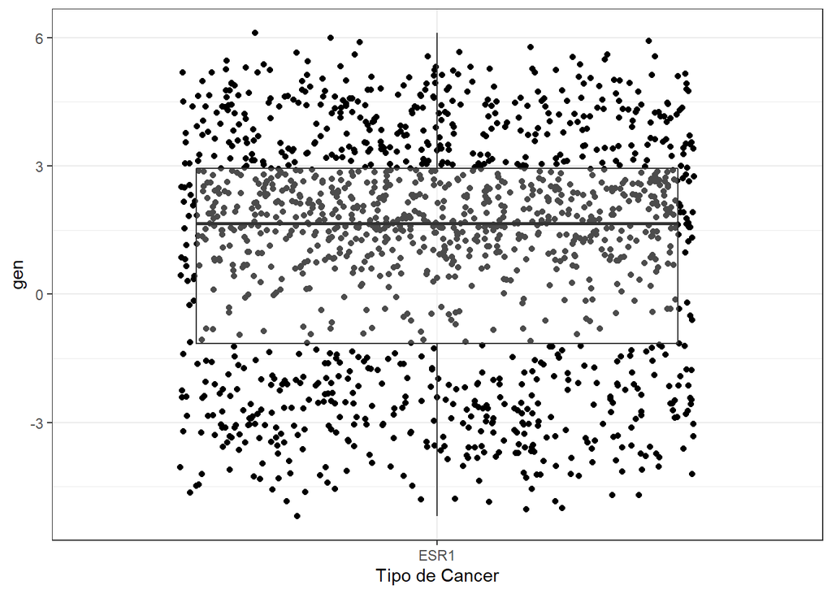

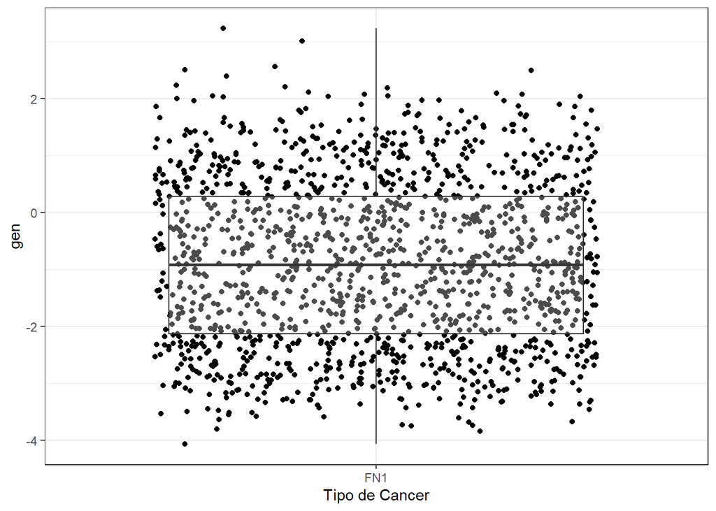

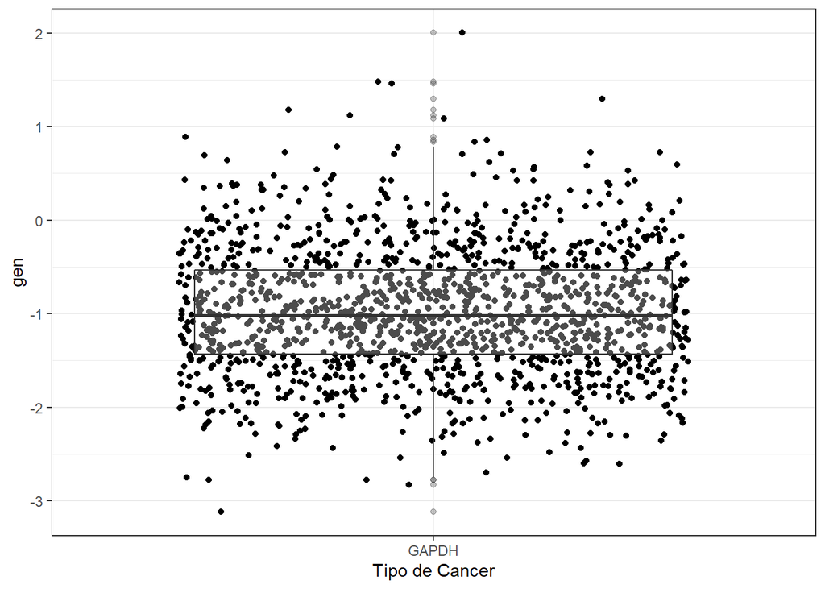

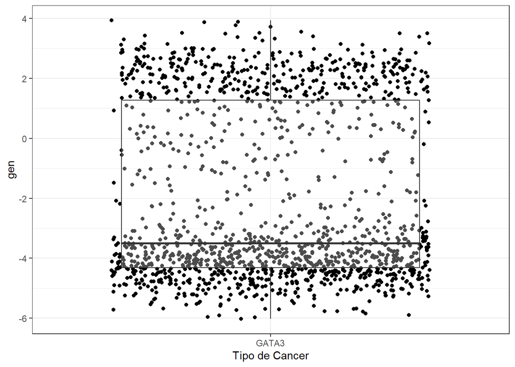

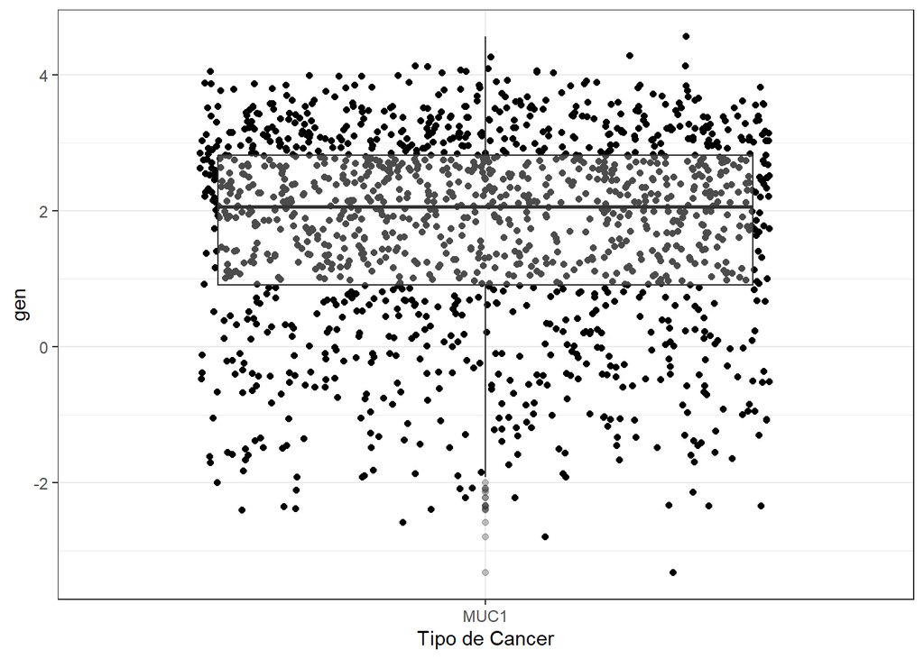

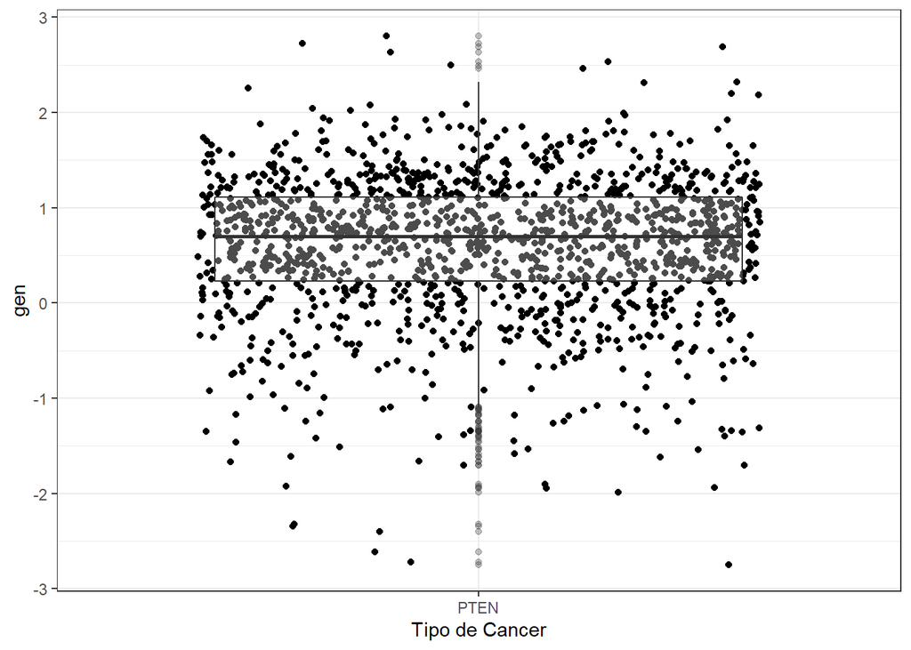

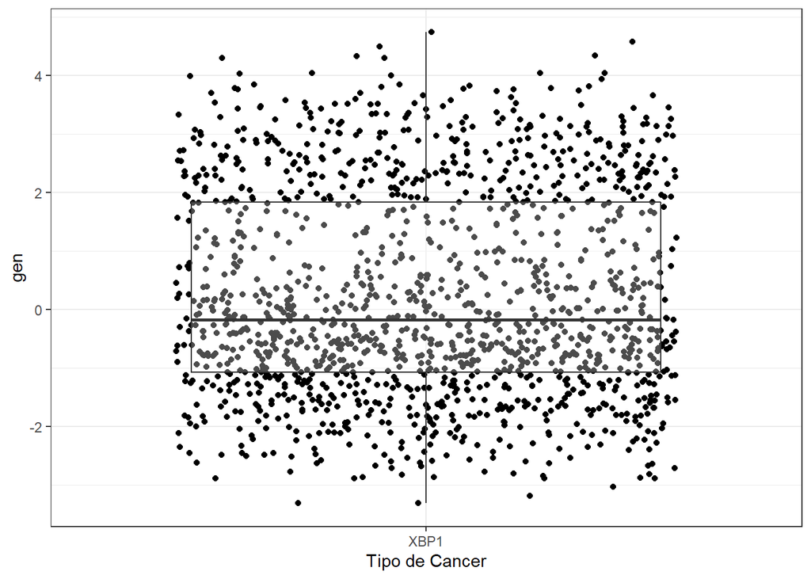

```r
# Escriba el código para crear la función tcga_boxplots

library(tidyverse)
tcga_boxplots=function(df1){


  o=df1[,c(1,2)]
  names(o)=c("fac1","ind1")
  nom=as.character(levels(o[,1]))
n=NULL


 for (i in 1:length(levels(o$fac1))){

    j=ggplot(o%>%filter(fac1==nom[i]),aes(fac1,ind1))+geom_jitter()+geom_boxplot(alpha=0.3)+xlab("Tipo de Cancer")+ylab("gen")+
theme_bw()+theme(legend.position='none')
    n[[i]]=j

}

  return(n)
}
tcga_boxplots(df_long)
```

### [0.5 PUNTOS] 2.2 Utilizando la función `lapply()` genera la lista `cancertype_boxplots` con las gráficas para cada tipo de cancer (cada tipo de dataset).

```r
# Escriba el código para generar la lista.
cancertype_boxplots=tcga_boxplots(df_long)
```

### [0.5 PUNTOS] 2.3 Guarde en el subdirectorio `result` el tercer plot de la lista `cancertype_boxplots` con el nombre `boxplot3.png`. La definición de a figura debe ser de 300dpi.

```r
# Escriba el código para guardar la tercera figura de la lista.
setwd("C:/Users/DELL/Desktop/Semestre 6/Bioinformática/GBI6_Examenfinal/result")
dir.create('./result')
png("boxplot3.png")
cancertype_boxplots[3]
```

```r
dev.off()
```

```r
pdf("boxplot3.pdf")
cancertype_boxplots[3]
```

```r
dev.off()
```

```r
ggsave(
  "boxplot3.pdf",
  dpi=300
  )
```

### [1 PUNTO] 2.4 Escriba la función `reg_gen_expression`, con el parámetro `gen`. En este caso la función visualizará una gráfica de nube de puntos (geom_point) y una regresión por tipo de “dataset”. La gráfica será de comparación de gen1 con gen2; por ejemplo en el eje “x” `GATA3` y en el eje “y”” `FN1`.

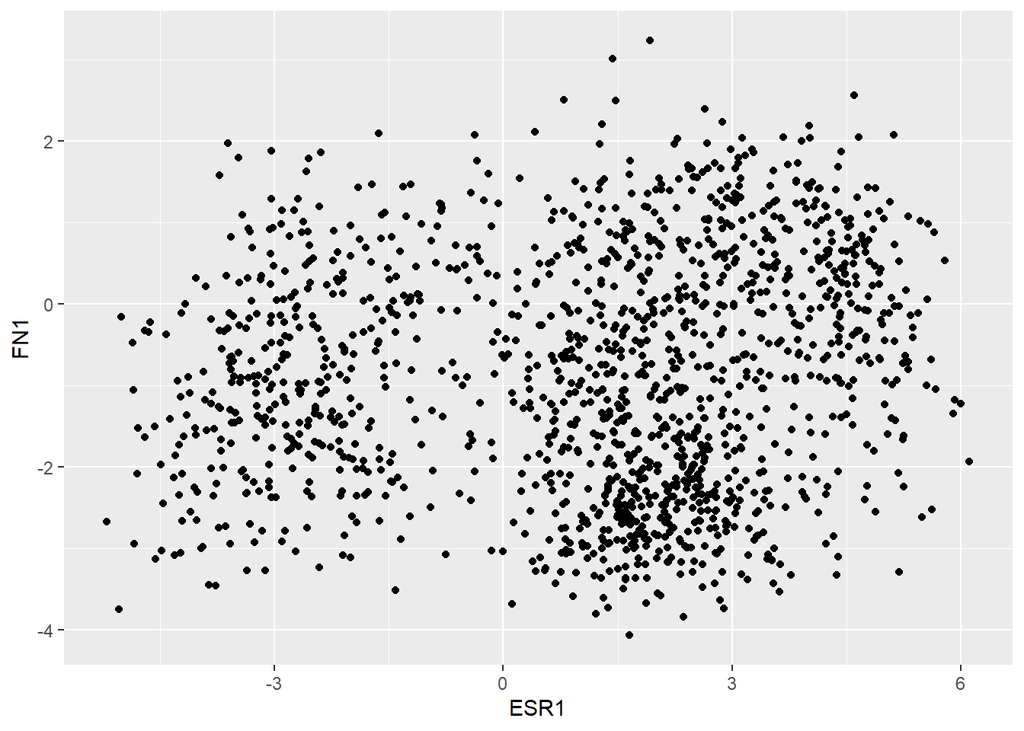

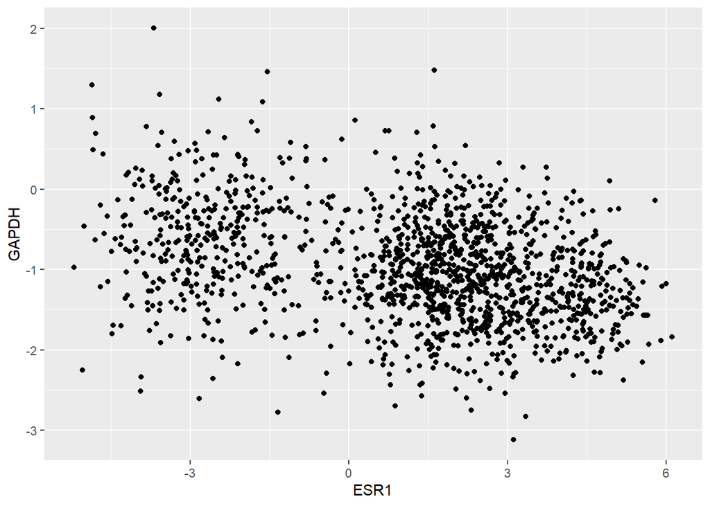

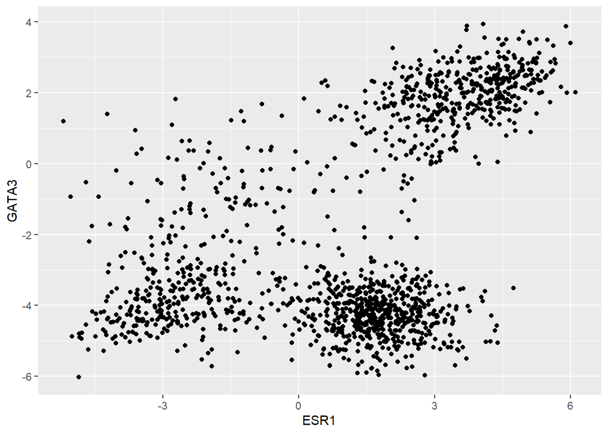

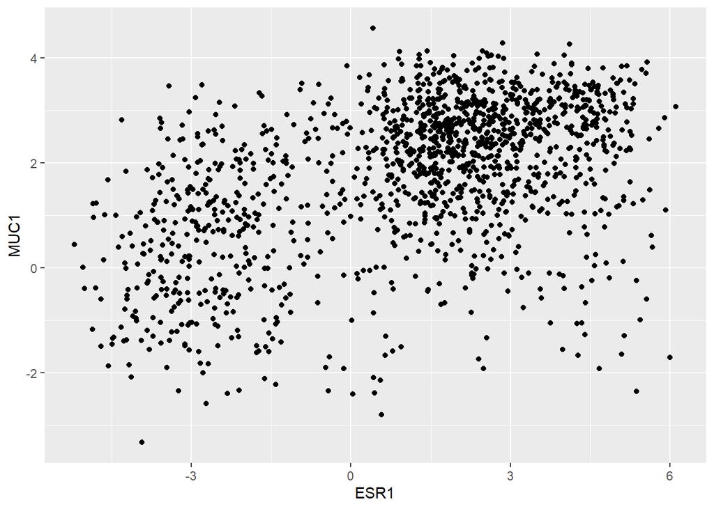

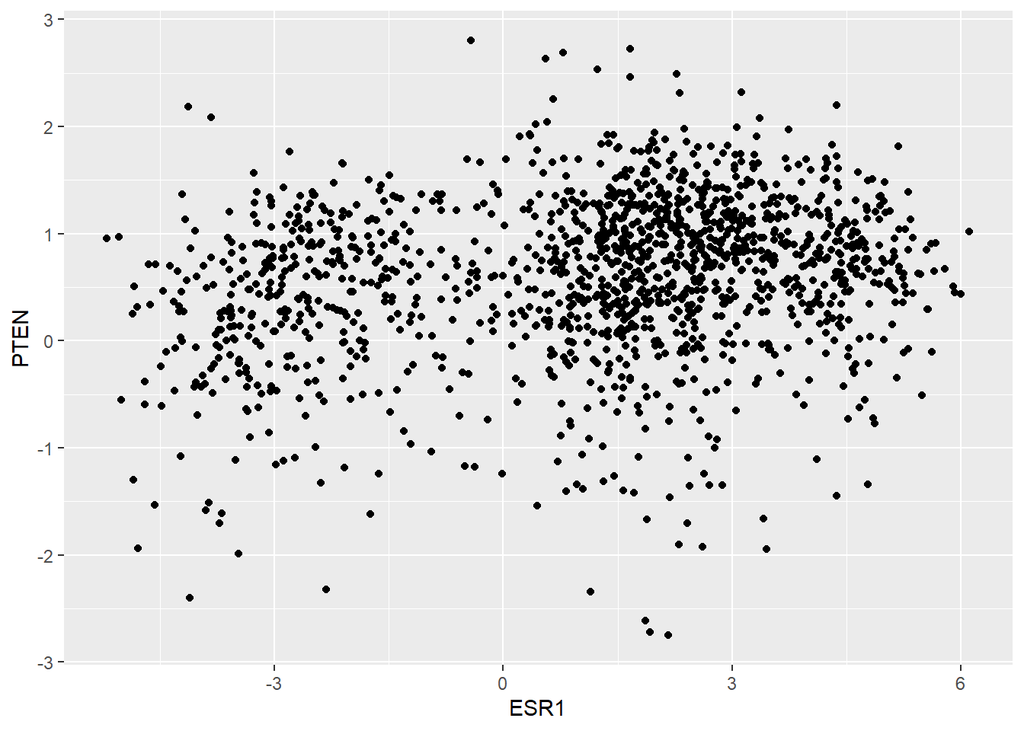

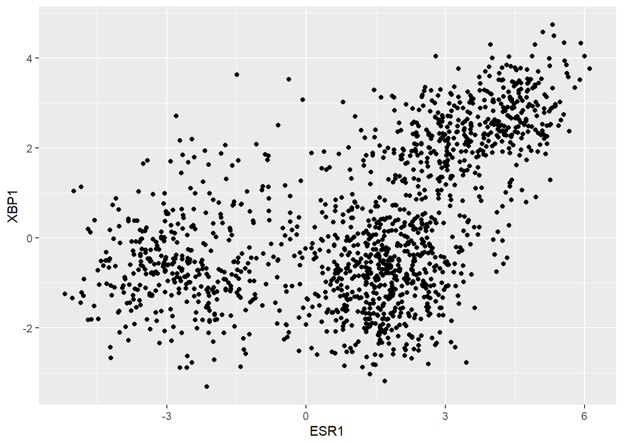

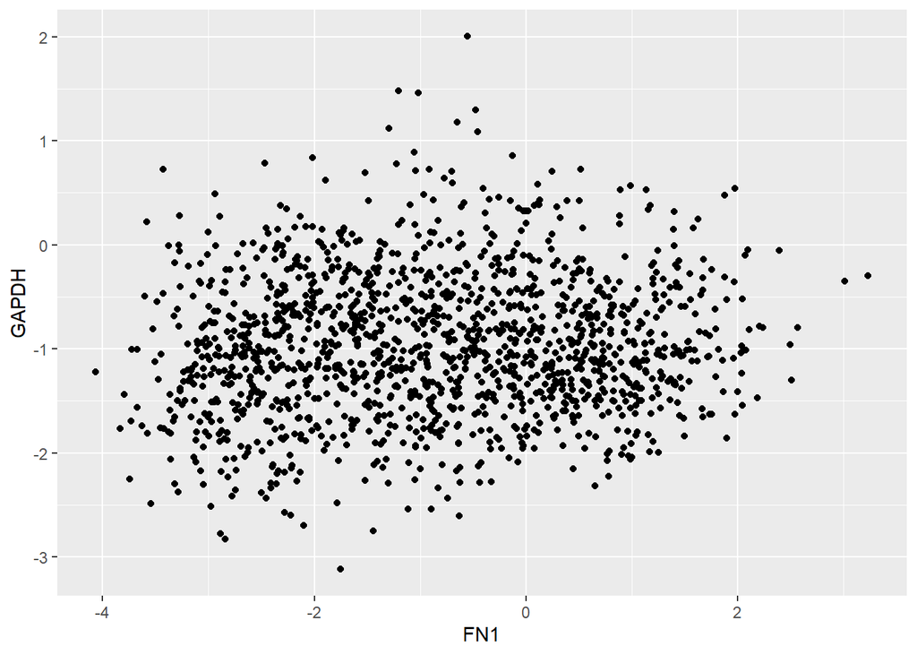

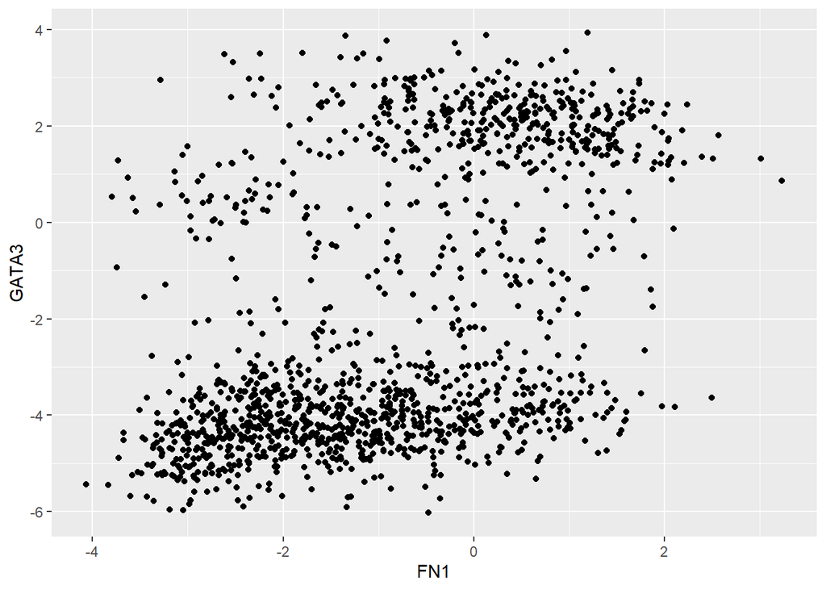

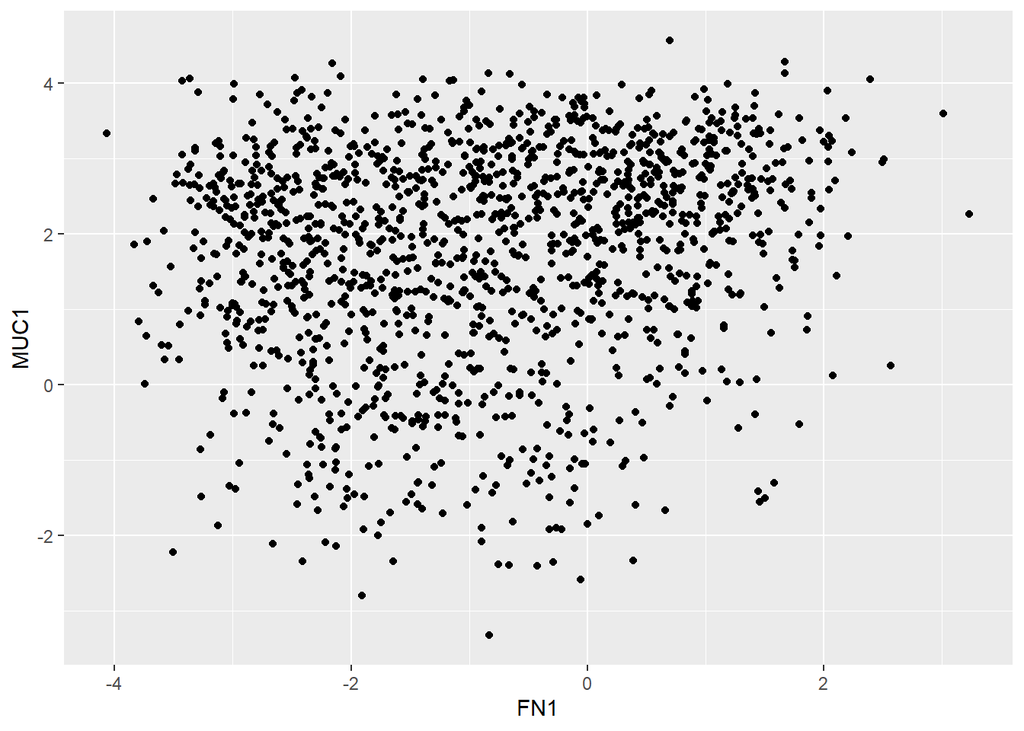

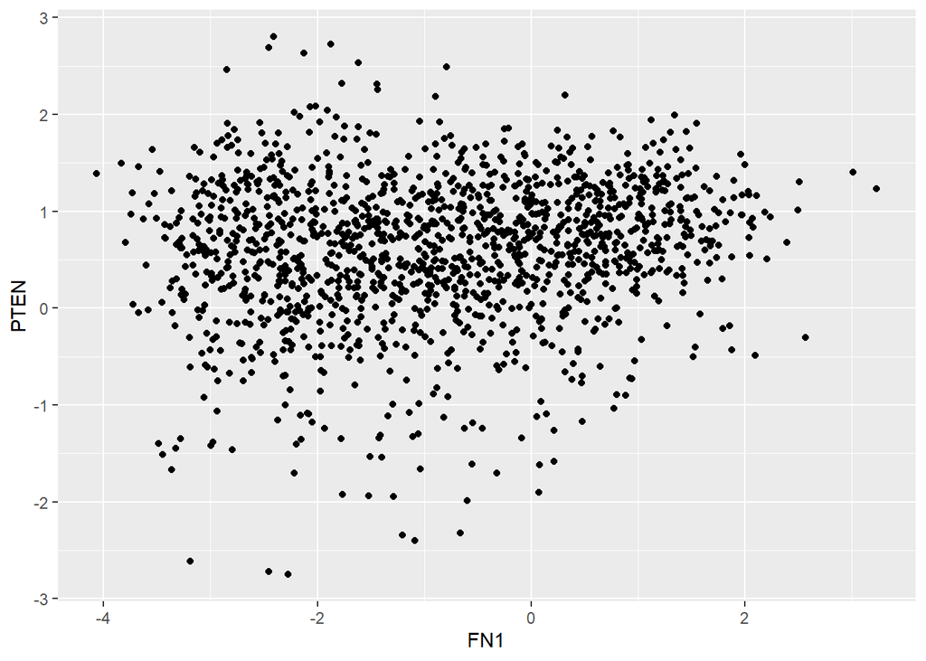

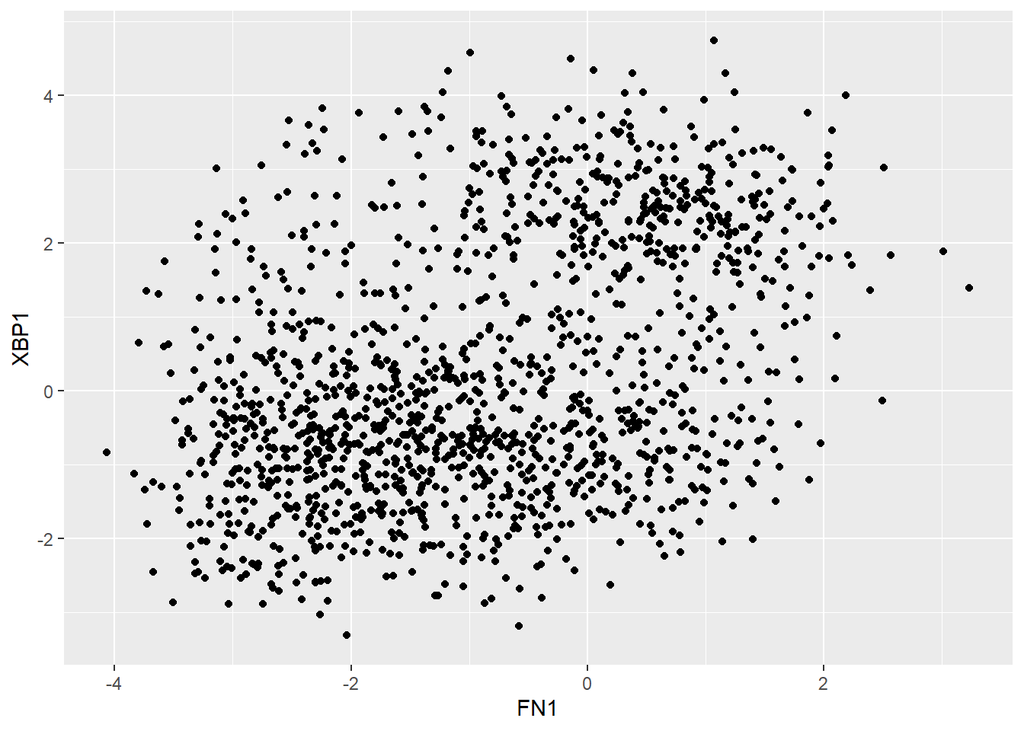

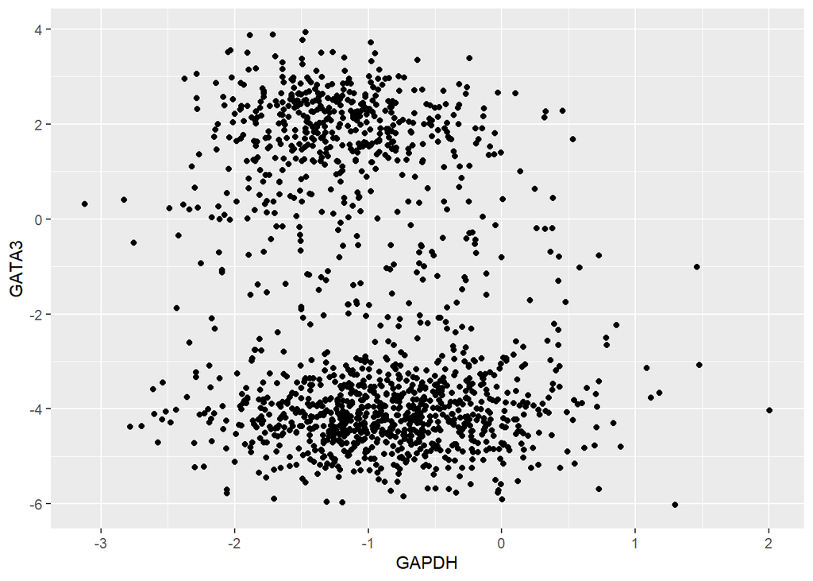

[9 more figures not shown]

```r
# Escriba aquí su función reg_gen_expression

reg_gen_expression=function(df){
  alm=combn(1:7,2)
  points=NULL
  df=df%>%select(gen,expresion_level)
  for (i in 1:ncol(alm)) {
    m=NULL
      x=NULL
      y=NULL

      m=c(alm[,i][1],alm[,i][2])


  nom=as.character(levels(df[,1]))

  x=df[which(df$gen==nom[m[1]]),][,2]
  y=df[which(df$gen==nom[m[2]]),][,2]
  dft=data.frame(x,y)
m=ggplot(data=dft,aes(x,y))+geom_point()+xlab(nom[m[1]])+ylab(nom[m[2]])

   points[[i]]=m

  }



  return(points)
}
reg_gen_expression(df_long)
```